# Species distribution modelling with Poisson point processes

Ian Flint and Roozbeh Valavi

2020-01-15

2020-01-21

## Species distribution modelling

The example data used in this tutorial comes form Fithian and others (2015).

## Envrionmental data

[figure not shown]

```r
# library(maptools)
library(raster)
library(sf)

grid_dir <- "data/grids"
vars <- list.files(grid_dir, pattern = ".tif$", full.names = TRUE)

# the border shapefile
ibra <- st_read("data/ibraone.shp", crs = 4283, quiet = TRUE)

# read the raster layers as a raster stack
nsw_stack <- stack(vars)
# set the coordinate system
crs(nsw_stack) <- CRS("+init=epsg:4283")

plot(nsw_stack)
```

```r
# library(maptools)
library(raster)
library(sf)

grid_dir <- "data/grids"
vars <- list.files(grid_dir, pattern = ".tif$", full.names = TRUE)

# the border shapefile
ibra <- st_read("data/ibraone.shp", crs = 4283, quiet = TRUE)

# read the raster layers as a raster stack
nsw_stack <- stack(vars)
# set the coordinate system
crs(nsw_stack) <- CRS("+init=epsg:4283")
# you can plot them by: plot(nsw_stack)
```

## Species data

The species data comes form Fithian and others (2015).

All the species starts with `euca` …

```r
# load Fithian et al (2015) species data
load("data/moddat.RData")

head(eucacine_moddat)
```

```
##   id     long       lat year accuracy  longlat   cells     bc01     bc02
## 1  1 150.0862 -34.60553 2000      100 15008622 6279811 13.63983 12.23118
## 2  2 150.2854 -34.44967 2000      100 15028535 6126927 13.24499 11.36682
## 3  3 150.0125 -34.80654 2000      100 15001250 6474021 13.71813 12.41187
## 4  4 150.0997 -34.96775 2000      100 15009972 6631876 13.09869 11.85747
## 5  5 149.8980 -34.85114 2007      100 14989800 6517680 13.29461 12.52573
## 6  6 149.7147 -35.01311 1999      100 14971468 6675426 12.81009 12.73738
##       bc04     bc05        bc06     bc12      bc14     bc21      bc28      bc32
## 1 1.645262 27.27752  1.09317458 693.4518  9.081451 26.44496 0.5211285 0.7648971
## 2 1.596420 26.22510  1.17330492 780.2014 10.506531 25.97984 0.6106081 0.8590701
## 3 1.652387 27.46763  1.06588304 681.5583  9.605835 26.38567 0.5021659 0.7421684
## 4 1.613784 26.41990  0.87655205 788.7050 10.496765 25.96847 0.5949574 0.8564287
## 5 1.699777 27.45464  0.58909386 653.2943  9.165375 26.40723 0.4897964 0.7353666
## 6 1.749456 27.40740 -0.01114328 677.7914 10.394196 26.34236 0.5267761 0.8032433
##        bc33      d2r      d2t     elev ibgd ibsb mvbf     rdjf     rjja
## 1 0.3000291   0.0000 76729.03 590.4653   98  394    3 188.9394 144.8310
## 2 0.3601428   0.0000 55561.12 692.9059   93  384    0 214.0642 160.9149
## 3 0.2900780   0.0000 91516.44 550.2057   98  394    0 183.8921 140.0840
## 4 0.3360529   0.0000 91472.76 639.3138   98  394    0 206.9004 166.6616
## 5 0.2770475 742.9186 84018.19 623.7888   98  394    0 175.7002 134.8407
## 6 0.2836685   0.0000 59406.70 696.1747   98  392    3 177.5476 147.8208
##        rsea      rugg sandsubs     slpe stre subs twmd  twmx      wpot xveg
## 1 0.2742345 10.927129        0 1.216894 0.76    5 6260  7542 -1.288309    0
## 2 0.2579768 18.860123        0 3.167662 0.00    7 8023 11071 -1.171590    0
## 3 0.2861401 19.935825        0 1.852355 0.00    5 7474  9066 -1.308515    1
## 4 0.2572912 15.468473        0 2.161766 0.00    5 7278  9110 -1.118788    1
## 5 0.2735702  8.366111        0 1.390608 1.00   15 8569 13911 -1.360653    0
## 6 0.2330509  5.964362        0 1.133822 0.00    6 8172 10061 -1.218756    1
```

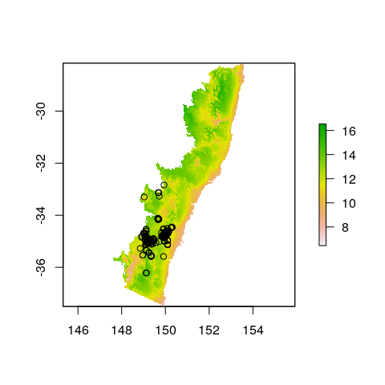

```r
plot(nsw_stack[[1]])
points(eucacine_moddat$long, eucacine_moddat$lat)
```

```r
# load Fithian et al (2015) species data
load("data/moddat.RData")

# show few rows and column in the species dataset
eucacine_moddat[1:5, 1:5]
```

```
##   id     long       lat year accuracy
## 1  1 150.0862 -34.60553 2000      100
## 2  2 150.2854 -34.44967 2000      100
## 3  3 150.0125 -34.80654 2000      100
## 4  4 150.0997 -34.96775 2000      100
## 5  5 149.8980 -34.85114 2007      100
```

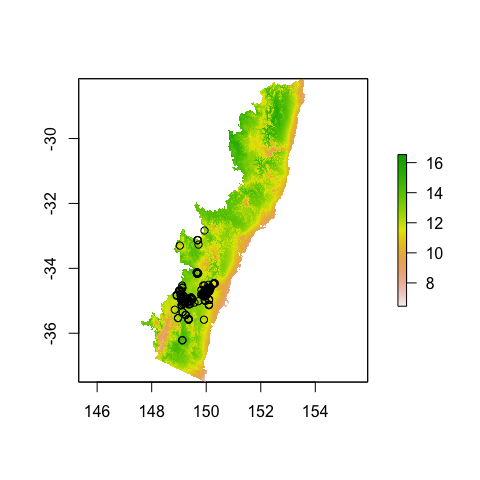

```r
# plot the sapecies on the raster map
plot(nsw_stack[[1]])
points(eucacine_moddat$long, eucacine_moddat$lat)
```

## Modelling with Maxent

Here we use `maxnet` package, the open-source version of `Maxent` in R.

```r
# load the libraries
library(maxnet)
library(dismo)  # for generating random points
```

Sampling random background from the landscape…

```r
# generate some random samples
rnd <- randomPoints(nsw_stack, n = 10000)

# extracting the values of points
background <- raster::extract(nsw_stack, rnd)
head(background)
```

```
##           bc02     bc04     bc05      bc12      bc14     bc21      bc32
## [1,]  9.299612 1.722115 20.32624 1248.2261 19.130325 23.60779 1.0000000
## [2,] 14.088867 1.851633 30.20234  832.7994  9.868927 26.31021 1.0000000
## [3,] 12.036219 1.644508 24.32661  851.0823 11.187012 25.11028 0.9625323
## [4,]  9.113000 1.231350 26.45982 1342.5192 14.765015 24.50705 1.0000000
## [5,] 14.172694 1.907220 30.14800  820.8109  9.981171 25.78006 0.9966347
## [6,] 12.476101 1.811902 27.05130  886.6918 10.866821 25.42090 0.9995425
##           bc33 mvbf     rjja        rsea      rugg twmd  twmx
## [1,] 0.6317487    0 346.8862 -0.10766015 41.195148 8650 11178
## [2,] 0.2190084    4 290.3501 -0.48947832  6.229008 8298  9616
## [3,] 0.4079552    0 172.1613  0.30830586 45.109512 6079  8519
## [4,] 0.6253353    0 280.3712  0.12412413 27.130716 6888  7994
## [5,] 0.3053993    0 238.2581 -0.08480092 12.993428 8957 13326
## [6,] 0.3540563    0 264.4060 -0.10911446 38.862095 7673  9514
```

```r
# check for any NA in the extracted values
anyNA(background)
```

```
## [1] TRUE
```

```r
# remove the NA values
background <- na.omit(background)
```

As the values in the presence data is already extracted, we just merge the data to make it ready for model fitting. Here, I make a `daata.frame` with only the covariates that is going to be used in model fitting.

```r
# subset the covariate in species data by raster
prcov <- eucacine_moddat[, names(nsw_stack)]

# now add them together
covariates <- rbind(prcov, background)
```

Here, we need to make a voctor of 1s and 0s (for presence and background points respectively). This shoudl be with the same order as the covariate data is provided.

```r
# make the presence and background points
# presnece (1s) and background (0s)
# the order should be the same as the order in the covariates
presences <- c(rep(1, nrow(eucacine_moddat)),
               rep(0, nrow(background)))

tmp <- Sys.time()
mxnet <- maxnet(p = presences,
                data = covariates,
                regmult = 1, # regularisation multiplier
                maxnet.formula(presences, covariates, classes = "lqph"))
Sys.time() - tmp
```

```
## Time difference of 15.98313 secs
```

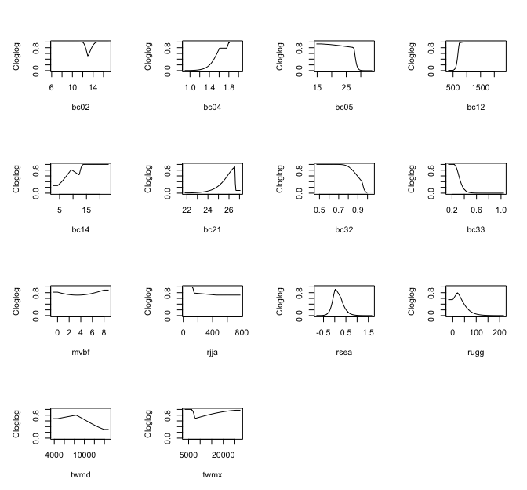

```r
# plot the fitted function
plot(mxnet, type = "cloglog")
```

### Pridicting on rasters

To predict this model on rasters, you need a `RasterStack` with all the covariates used in model fitting. The names of the covariates in the `RasterStack` must be exactly the same. This is done through `raster` package (already loaded with `dismo` pcakage).

There are different option for scaling the raw output of `maxnet` including the **link**, **exponential**, **logistic** and recently introduced **cloglog**. For more information about these option please read Phillips et al. (2017).

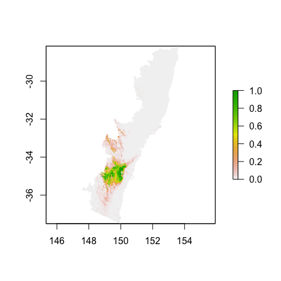

```r
max_pred <- raster::predict(object = nsw_stack, model = mxnet, type = "cloglog")
# plot the prediction
plot(max_pred)
```

## Modelling with Poisson point processes